```python
from IPython.display import HTML
HTML('''
<script src="https://cdnjs.cloudflare.com/ajax/libs/jquery/2.0.3/jquery.min.
js"></script>
<script>
code_show=true;
function code_toggle() {
if (code_show){
$('div.jp-CodeCell > div.jp-Cell-inputWrapper').hide();
} else {
$('div.jp-CodeCell > div.jp-Cell-inputWrapper').show();
}
code_show = !code_show
}
$( document ).ready(code_toggle);
</script>
<form action="javascript:code_toggle()"><input type="submit"
value="Click here to toggle on/off the raw code."></form>
''')
```

```python
from IPython.core.display import HTML
HTML("""
<style>
.output_png {
    display: table-cell;
    text-align: center;
    vertical-align: middle;
}
</style>
""")
```

[figure not shown]

# Executive Summary

This study highlights the value of the `US Imports - Automated Manifest System Shipments 2018-2020` or `AMS` dataset in understanding the effects of policies on global supply chains and international trade. Leveraging big data techniques, this study analyzed the dataset to gain insights into the movement of shipments and ocean freights and the governing policies behind them. The results underscored the importance of trade agreements, shipment delays, the COVID-19 pandemic, and geopolitical risks in shaping the shipping industry. The study emphasizes the need for evaluating trade policies, improving shipment processes, and adapting to disruptions. To further enhance similar works, future recommendations include expanding the timeline coverage and exploring the impact of tariff policies and other freight modes.

The key to accessing this data was its free subscription in `AWS Data Exchange` and its readiness for transfer between S3 buckets. After transferring the data, we were able to easily perform initial exploratory data analysis (EDA) using `EMR`. We had set up instances with 1 core and 3 worker nodes, allowing us to efficiently shortlist the files. Once we had identified the key datasets (header, shipper, and container), we converted them to the `Parquet` format. This conversion resulted in a significant file size reduction of around 82%, leading to savings in storage and faster processing. We then ran the EDA on the `EMR` cluster to generate our descriptive analytics. Each of the PySpark dataframes was converted to pandas format and exported as `csv` files written to our S3 bucket. To create the report and visualizations, we transferred the extracted `csv` files to Jojie using AWS CLI.

The technical analysis focused on preprocessing the `AMS` dataset using big data techniques to explore the influence of policies on global and transnational shipments. Descriptive analytics provided insights into the dynamics of international trade, emphasizing the significance of trade agreements, shipment delays, the COVID-19 pandemic, and geopolitical risks. The study highlights the importance of evaluating trade policies, improving shipment processes, and adapting to disruptions. Future research suggestions involve expanding the timeline coverage and investigating the impact of tariff policies and other freight modes to gain a comprehensive understanding of trade dynamics.

Combining cloud (AWS) and big data techniques has allowed us to maximize the insights we can glean from the data. Through the techniques we applied, we discovered numerous opportunities to enhance its utilization while reducing costs. To advance knowledge in this field, it is recommended that future studies expand the timeline coverage beyond 2018-2020. This expansion will enable a broader understanding of trade dynamics and their evolution over time. Moreover, investigating the impact of tariff policies and exploring other freight modes beyond ocean shipments would provide valuable insights into the broader transportation landscape and its influence on global trade. Conducting these studies would contribute to a deeper understanding of policy effects and assist in informed decision-making within the realm of international trade and supply chain management.

**List of Figures**  
**Figure 1.** Countries with the Highest Number of Shipments  
**Figure 2.** Countries with the Lowest Number of Shipments  
**Figure 3.** Shipments-Country Density  
**Figure 4.** US FTA Partners with the Highest Number of Shipments  
**Figure 5.** Non-US FTA Partners with the Highest Number of Shipments  
**Figure 6.** Distribution of Shipment Arrival Punctuality  
**Figure 7.** Shippers with the Highest Shipment Delays  
**Figure 8.** Countries with the Highest Shipment Delays  
**Figure 9.** US FTA Partners with the Highest Shipment Delays  
**Figure 10.** Non-US FTA Partners with the Highest Shipment Delays  
**Figure 11.** Trend in Total Monthly Shipments  
**Figure 12.** Trend in Total Monthly Shipments of US FTA Partners  
**Figure 13.** Trend in Total Monthly Shipments of Non-US FTA Partners  
**Figure 14.** Trend in Total Monthly Shipments of Russia and Ukraine  
**Figure 15.** Trend in Lebanon's Monthly Shipment

**List of Images**  
**Image 1.** AMS Dataset Tables  
**Image 2.** AMS Dataset Size  
**Image 3.** EMR Cluster Information Summary  
**Image 4.** EMR Cluster Properties  
**Image 5.** AMS EMR Instances  
**Image 6.** Methodology

**List of Tables**  
**Table 1.** Table Row Count  
**Table 2.** Header Table  
**Table 3.** Shipper Table  
**Table 4.** Container Table  
**Table 5.** Territories and Others  
**Table 6.** US FTA Partners  
**Table 7.** Shipper-Country Map

# Problem Statement

The policies governing global supply chain, international trade, and tariffs can have a significant influence on the movement of shipments worldwide. However, comprehending the effects of these factors and their implications for businesses and economies necessitates a thorough analysis and exploration.

To shed light on these dynamics, we will leverage the `US Imports – Automated Manifest System Shipments 2018-2020` or `AMS` dataset. Through descriptive analytics, our objective is to address the following key questions:

1. Which countries exhibit the highest shipment volumes? How does the presence of an active free trade agreement with the United States impact this?
2. Which shippers and countries experience the most delays? What may be the implications of these delayed shipments?
3. How do the number and scheduling of shipments evolve over time?
4. How do unforeseen events, such as the COVID-19 pandemic, influence shipment trends?

# Motivation

Recent events, such as the financial crisis of 2008-2009 and the global lockdown due to the COVID-19 pandemic, have demonstrated the potential impact on the global supply chain and international trade. While the concept of deglobalization has been debunked [(Shulga, 2023)](https://www.imf.org/en/Publications/fandd/issues/2023/06/growing-threats-to-global-trade-goldberg-reed), it is evident that external factors can significantly affect these domains.

Efficiencies and cost savings are key benefits of a global supply chain, enabling businesses to reach customers worldwide quickly and cost-effectively [(Williams, 2023)](https://www.americanexpress.com/en-us/business/trends-and-insights/articles/what-is-a-global-supply-chain/). However, factors like tariffs [(York, 2018)](https://taxfoundation.org/impact-of-tariffs-free-trade/), protectionism [(Shulga, 2023)](https://www.imf.org/en/Publications/fandd/issues/2023/06/growing-threats-to-global-trade-goldberg-reed) [(York, 2018)](https://taxfoundation.org/impact-of-tariffs-free-trade/), and free trade agreements can create binding constraints on ocean freight movements. Moreover, geopolitical turmoil and environmental disasters [(Williams, 2023)](https://www.americanexpress.com/en-us/business/trends-and-insights/articles/what-is-a-global-supply-chain/) pose additional challenges for the global supply chain.

To address these complexities, our analysis of the `AMS` dataset aims to provide valuable insights into the effects of these factors on the import landscape. By exploring trade patterns, identifying disruptions in supply chains, and understanding business resilience, we can empower stakeholders to make informed decisions and strategic plans. This analysis will enable policymakers, businesses, and researchers to gain a deeper understanding of the dynamics within the ocean freight industry, adapt policies and agreements when necessary, and enhance decision-making processes.

By examining the interplay among global supply chain dynamics, international trade policies, and the impact of external events, this study shall contribute to a broader understanding of how businesses can navigate challenges, promote growth, and foster resilience in the face of a rapidly changing transnational trade landscape.

# Data Source and Exploration

The `AMS` dataset [(Enigma, n.d.)](https://aws.amazon.com/marketplace/pp/prodview-stk4wn3mbhx24#offers) is a comprehensive collection of millions of data points pertaining to shipments to various ports in the United States. This dataset is meticulously compiled by the [US Customs and Border Protection](https://www.cbp.gov) and encompasses vital information such as manufacturer details, shipper contact information, vessel country codes, carrier information, and cargo descriptions. Its extensive scope makes it an invaluable resource for analyzing global supply chains, investigating international trade dynamics, examining the effects of tariffs, and probing trafficking felonies. For this study, the primary focus revolves around the analysis of global supply chains and international trade, as these aspects significantly shape the research objectives.

The study places particular emphasis on exploring the fully normalized relational database structure of the `AMS` dataset, which encompasses three key tables: the `header`, `shipper`, and `container` tables (refer to Image 1). The `header` table serves as the central repository of vessel details, shipment summaries, as well as target and actual arrival information. Complementing this, the `shipper` table provides insights into the companies responsible for shipping the vessels. Lastly, the `container` table delineates the various container types employed in each shipment.

[figure not shown]

**Image 1. AMS Dataset Tables.**  
*Different tables under the AMS dataset and the corresponding objects they contain.*

The dataset has a total size of `63.7GB` distributed across 33 separate files covering the years 2018, 2019, and 2020. For this study, we will be utilizing `25.4GB` (refer to Image 2) of data from the three tables mentioned above.

[figure not shown]

**Image 2. AMS Dataset Size.**  
*Total size of the dataset to be utilized for this project.*

*Data Description*

The `AMS` dataset, available on `AWS Data Exchange`, offers valuable insights into the intricacies of global supply chains, international trade, and tariff effects. To access the dataset, a free subscription to `AWS Data Exchange` is required, and subsequent data processing involves transferring the files in `CSV` format to an S3 bucket. The dataset, along with its comprehensive description, can be accessed [here](https://ap-northeast-1.console.aws.amazon.com/dataexchange/home?region=ap-northeast-1#/products/prodview-stk4wn3mbhx24).

Table 1 provides an overview of the row count for each table within the `AMS` dataset. Notably, a specific filter was applied to the `Header Row Count`, which involved considering data entries with non-null values for `actual_arrival_date` and `vessel_country_code`. This filter ensures that the analysis focuses on shipments with available and relevant information. Furthermore, the dataset covers target and actual arrival dates spanning the years 2018 to 2020, allowing for a comprehensive examination of shipment trends during this period.

| Table | Row Count |
| --- | --- |
| `header` | `53,844,894` |
| `shipper` | `40,240,366` |
| `container` | `85,503,338` |

**Table 1. Table Row Count.**  
*Row count for tables header, shipper, and container from 2018 to 2020.*

As mentioned earlier, the three key tables comprise of different information regarding the shipments. The following tables provide information about `header` (Table 2), `shipper` (Table 3), and `container` (Table 4) features and their brief descriptions.

| Feature | Description | Remarks |
| --- | --- | --- |
| `identifier` | unique identifier of a shipment, used to join with other tables |  |
| `vessel_country_code` | two-character country code of the shipment |  |
| `estimated_arrival_date` | date when the shipment was estimated to arrive |  |
| `actual_arrival_date` | date when the shipment actually arrived |  |
| `actual_year` | `yyyy` value (year) of the `actual_arrival_date` | *feature-engineered* |
| `actual_month` | `MM` value (month) of the `actual_arrival_date` | *feature-engineered* |
| `estimated_year` | `yyyy` value (year) of the `estimated_arrival_date` | *feature-engineered* |
| `estimated_month` | `MM` value (month) of the `estimated_arrival_date` | *feature-engineered* |
| `estimated_year_month` | `yyyy-MM` value (year-month) of the `estimated_arrival_date` | *feature-engineered* |
| `is_delayed` | `delayed` if `actual_arrival_date` > `estimated_arrival_date` | *feature-engineered* |
|  | `early` if `actual_arrival_date` < `estimated_arrival_date` | *feature-engineered* |
|  | `on schedule` if `actual_arrival_date` == `estimated_arrival_date` | *feature-engineered* |

**Table 2. Header Table.**  
*Features and descriptions for `header` table.*

| Feature | Description |
| --- | --- |
| `identifier` | used to join with `header` table |
| `shipper_party_name` | name of the shipper |

**Table 3. Shipper Table.**  
*Features and descriptions for `shipper` table.*

| Feature | Description |
| --- | --- |
| `identifier` | used to join with `header` table |
| `type_of_service` | service in relation to the container for a particular shipment |

**Table 4. Container Table.**  
*Features and descriptions for `container` table.*

*Data Limitation*

The dataset for this study consists of multiple files stored in the S3 bucket of the data source. To optimize the analysis, we have carefully selected the latest extracts based on their extraction dates, ensuring access to the most up-to-date and comprehensive data.

To maintain the integrity of the analysis and focus on relevant insights, we have excluded data points outside the timeframe of 2018 to 2020. These excluded records typically contain a limited number of data points, often used for testing purposes, and may only consist of a few hundred or thousand rows. Including such records in our analysis could introduce potential biases and impact accurate month-on-month or year-on-year comparisons.

The study primarily focuses on three specific tables within the dataset to explore temporal aspects, including the volume of shipments, country performance, shipper performance, and commonly used services. These tables provide valuable insights into the dynamics of the dataset. However, analyzing port and shipper geographic details was not feasible due to the extensive mapping required for addresses, the need for standardizing city, state, and country names, and the significant cleansing efforts involved. Given the dataset's size, consisting of millions of data points, these tasks would have been resource-intensive and thus, will not be covered by this study.

It's important to note that fields not specifically mentioned in this study were not utilized in the analysis. However, these unused fields could be explored in future studies or analyses, providing additional insights and expanding the scope of understanding within the dataset.

*EMR Details*

The following images (Image 3, 4, and 5) show the EMR used for processing the dataset, and their pertinent details.

[figure not shown]

**Image 3. EMR Cluster Information Summary.**  
*Summary of information regarding the EMR Cluster used.*

[figure not shown]

**Image 4. EMR Cluster Properties.**  
*Overview of the properties of the EMR Cluster used.*

[figure not shown]

**Image 5. AMS EMR Instances.**  
*Overview of the instances under the EMR Cluster used.*

# Methodology

[figure not shown]

**Image 6. Methodology.**  
*Overview of the steps followed for this study.*

*Data Collection*

We subscribed to the `AMS` dataset within the AWS Data Exchange Subscription to gain access to the dataset.

**S3 File Transfer**

We established a dedicated S3 bucket and performed the necessary data transfer from the original `AMS` S3 bucket. This transfer was executed using the AWS user interface.

*Data Exploration*

To conduct a thorough exploratory data analysis (EDA), we leveraged the power of `EMR` and the flexibility of `PySpark`. This approach was particularly advantageous given the large size of the dataset and the presence of multiple files.

By harnessing the capabilities of `EMR` and `PySpark`, we were able to efficiently process and analyze the interrelationships between the various files. During the initial investigation, we confirmed that the `header` table contains the primary transactional details, and subsequently decided to include the shipper and container files for a comprehensive analysis.

One notable advantage of using `EMR` and `PySpark` was the ability to handle the entire dataset without any limitations. Even with the fully loaded files for each table, the query performance remained remarkably fast, allowing us to retrieve and explore insights more quickly.

**Conversion to Parquet**

To further enhance query speed and reduce file size, we converted all 9 files (3 files for each table) into 3 separate Parquet objects. This conversion resulted in a file size reduction from the original `25.4GB` down to only `4.5GB`.

*Data Filtering*

Based on the initial EDA, we identified specific filters for rows where the arrival and estimated dates fall outside the 2018-2020 range. We also filtered out rows where the `vessel_country_code` and `actual_arrival_date` are null. We also did not perform any data cleaning as the needed fields are already sufficient.

*Feature Engineering*

Additionally, we performed feature engineering on columns derived from the `estimated_arrival_date` and `actual_arrival_date`, including extracting the year, month, and year-month format. We also calculated an `is_delayed` field based on the estimated and actual arrival dates. These engineered features facilitated easier query building and report generation. The code for these transformations was implemented during the loading of the Parquet files for the `header` table.

*Data Extraction*

Due to the efficient processing on `EMR`, we did not limit the data, as it could be processed within a few seconds. We converted the `PySpark` dataframes to pandas dataframes and wrote the extracted data into `CSV` files, which were saved in the S3 bucket under the directory `extracted_csv/`. These tasks were performed in a separate notebook titled `bdcc-lab-2.ipynb`.

*Exploratory Data Analysis and Report Generation*

Descriptive analytics reports were generated using `Matplotlib` module, taking advantage of the fact that the data now fits in memory. The findings and conclusions for each report are documented in the remaining sections of the notebook.

# Results and Discussion

```python
import numpy as np
import pandas as pd

# for visualization
from mpl_toolkits.axes_grid1 import make_axes_locatable
import geopandas as gpd
import matplotlib.colors as mcolors
import matplotlib.pyplot as plt
import matplotlib.ticker as tick
import pickle
import seaborn as sns

import warnings
warnings.filterwarnings('ignore')
```

```python
mean_country_delay_and_early = pd.read_csv(
    'data/mean_country_delay_and_early.csv'
)
mean_country_delay_and_early = mean_country_delay_and_early.sort_values(
    'count', ascending=True
)
```

We conducted an exploratory data analysis (EDA) on the extracted tables from the `AWS` dataset to address our problem statements. The EDA consisted of four main components: `Shipments`, `Delays`, `Trends`, and `Disruptions`.

In the `Shipments` analysis, we examined the number of shipments per country as recorded in the dataset. This allowed us to explore the trade relationships between these countries and the United States.

Under the `Delays` section, we investigated the extent of delays in shipments. Specifically, we analyzed the number of days by which shipments from different countries and shippers were delayed.

For the `Trends` component, we examined the monthly pattern of shipment volumes from 2018 to 2020. This analysis provided us with an overview of the fluctuation in shipment numbers over time.

Lastly, we explored `Disruptions` to identify any current events that may have impacted shipments during the covered period. This analysis helped us understand external factors that could potentially influence the shipment data.

*Shipments*

To focus specifically on the trade relationship between countries and the United States, we temporarily removed information related to the United States from the dataset. Additionally, we excluded locations falling under the following categories: (1) locations that no longer exist, (2) US territories, and (3) territories claimed by another official country. The excluded locations are listed below in Table 5.

| Code | Name | Remarks |
| --- | --- | --- |
| GU | Guam | US territory |
| AQ | Antarctica | governed by 30 different countries |
| PR | Puerto Rico | US territory |
| VI | US Virgin Islands | US territory |
| EN | Ascension Island | British overseas territory |
| MP | Northern Mariana Islands | US territory |
| CW | Curaçao | Netherlands constituent country |
| AN | Netherlands Antilles | dissolved in 2010 |
| UM | United States Minor Outlying Islands | US territory |
| AS | American Samoa | US territory |
| PN | Pitcairn Islands | British overseas territory |
| DD | Dronning Maud Land | Norway dependent territory |
| TF | French Southern and Antarctic Lands | France overseas territory |

**Table 5. Territories and Others.**  
*List of other locations excluded in the analysis, assumed to be within others' territorial jurisdiction.*

```python
not_countries = mean_country_delay_and_early[
    mean_country_delay_and_early['country_name'].isna()
]['vessel_country_code'].tolist()
```

```python
df_all_countries = mean_country_delay_and_early.drop(
    mean_country_delay_and_early[
        (mean_country_delay_and_early['vessel_country_code'] == 'US') |
        (mean_country_delay_and_early[
            'vessel_country_code'
        ].isin(not_countries))
    ].index
)
```

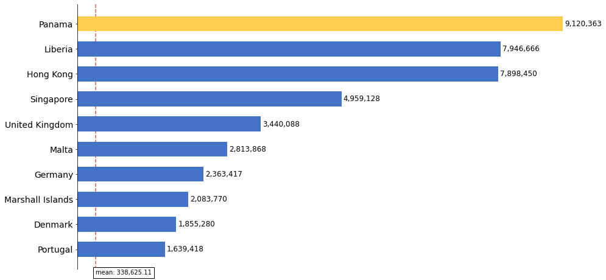

```python
# calculate mean of shipment count
mean_count = df_all_countries['count'].mean()

# figure size
fig, ax = plt.subplots(figsize=(15, 8))

# determine the color for the bars
bar_colors = ['#4472C4'] * len(df_all_countries)
max_idx = df_all_countries['count'].argmax()
bar_colors[max_idx] = '#ffcd4d'

# horizontal bar plot
works = plt.barh(df_all_countries['country_name'][-10:],
                 df_all_countries['count'][-10:],
                 height=0.60,
                 color=bar_colors[-10:])

# axis labels
ax.spines[['right', 'top', 'bottom']].set_visible(False)
ax.xaxis.set_visible(False)
formatter = tick.StrMethodFormatter('{x:,.0f}')
ax.xaxis.set_major_formatter(formatter)
ax.bar_label(works,
             labels=[f'{x:,.0f}' for x in df_all_countries['count'][-10:]],
             padding=3,
             color='#000000',
             fontsize=12,
             label_type='edge',
             fontweight='regular')
ax.yaxis.set_tick_params(labelsize=14)
ax.axvline(x=mean_count, zorder=0, color='indianred', ls='--', lw=1.5)
ax.text(x=mean_count, y=-1.0, s=f'mean: {mean_count:,.2f}', ha='left',
        fontsize=10, bbox=dict(facecolor='white', edgecolor='black', ls='-'))

# Show Plot
plt.show()
```

**Figure 1. Countries with the Highest Number of Shipments.**  
*These are the ten countries with the highest recorded shipments from 2018 to 2020.*

The top countries in terms of the number of shipments, as shown in Figure 1, include Panama, Liberia, and Hong Kong. These countries exhibit different trade relationships with the United States, which contributes to their shipment volumes.

Panama stands out as a significant trading partner with the United States, benefiting from an existing and comprehensive free trade agreement, among other trade agreements [(International Trade Administration, n.d.)](https://www.trade.gov/country-commercial-guides/panama-trade-agreements). With its strategic location and the Panama Canal facilitating faster transportation, it is not surprising that Panama ranks highest in terms of shipments. The accessibility and proximity to the United States play a crucial role in fostering strong trade ties.

Although Liberia and Hong Kong do not have a formal free trade agreement with the United States, they have established trade and investment agreements that provide them with certain trade benefits. Liberia, for instance, enjoys duty-free and preferential trade benefits, as well as access to the US market through its three trade and investment agreements with the United States [(International Trade Administration, n.d.)](https://www.trade.gov/country-commercial-guides/liberia-trade-agreements).

In the case of Hong Kong, its unique position between the United States and China positions it as an important trade hub for US firms seeking to expand into the Chinese market [(International Trade Administration, n.d.)](https://www.trade.gov/knowledge-product/hong-kong-macau-trade-agreements). Hong Kong maximizes trade opportunities, benefiting from both its trade relationship with the United States and its closer ties with mainland China, with which it has a free trade agreement [(International Trade Administration, n.d.)](https://www.trade.gov/knowledge-product/hong-kong-macau-trade-agreements).

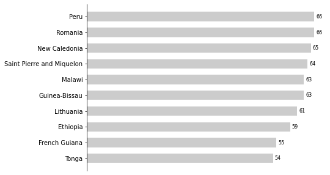

```python
# figure size
fig, ax = plt.subplots(figsize=(7, 5))

# determine the color for the bars
bar_colors = ['#CCCCCC'] * len(df_all_countries)
max_idx = df_all_countries['count'].argmax()
bar_colors[max_idx] = '#CCCCCC'

# horizontal bar plot
works = plt.barh(df_all_countries['country_name'][0:10],
                 df_all_countries['count'][0:10],
                 height=0.60,
                 color=bar_colors[0:10])

# axis labels
ax.spines[['right', 'top', 'bottom']].set_visible(False)
ax.xaxis.set_visible(False)
formatter = tick.StrMethodFormatter('{x:,.0f}')
ax.xaxis.set_major_formatter(formatter)
ax.bar_label(works,
             labels=[f'{x:,.0f}' for x in df_all_countries['count'][0:10]],
             padding=3,
             color='#000000',
             fontsize=8,
             label_type='edge',
             fontweight='regular')
ax.yaxis.set_tick_params(labelsize=10)

# Show Plot
plt.show()
```

**Figure 2. Countries with the Lowest Number of Shipments.**  
*These are the ten countries with the lowest recorded shipments from 2018 to 2020.*

Peru's inclusion in this group is surprising because it has an active Free Trade Agreement (FTA) with the US and is geographically close to the US. The presence of an FTA typically facilitates trade by reducing trade barriers and promoting economic cooperation. However, despite these advantages, Peru's shipment volume remains low.

One potential factor that could contribute to Peru's low shipment volume is the absence of a bilateral taxation treaty [(International Trade Agreement, n.d.)](https://www.trade.gov/country-commercial-guides/peru-trade-agreements) between Peru and the US. This absence may lead to challenges related to double taxation for Peruvian businesses operating in the US. Double taxation [(Hayes, 2022)](https://www.investopedia.com/terms/b/bilateral-tax-agreement.asp#:~:text=A%20bilateral%20tax%20agreement%20is,the%20investor%27s%20earnings%20may%20arise) occurs when a business is taxed on its income in both its home country (Peru) and the foreign country (US). This can create additional costs and administrative burdens for Peruvian businesses, which may impact their trade activities and discourage higher shipment volumes.

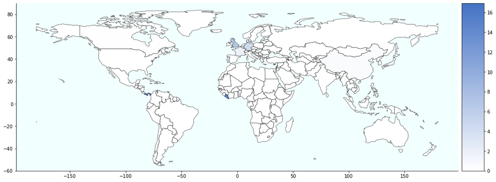

```python
# Load the dictionary from the file
with open('country_dict.pkl', 'rb') as file:
    country_dict = pickle.load(file)

with open('country_dict_df.pkl', 'rb') as file:
    country_dict_df = pickle.load(file)

# load the world shapefile data
world = gpd.read_file(gpd.datasets.get_path('naturalearth_lowres'))

# define the countries to highlight and their respective weights
country_count = (df_all_countries[['vessel_country_code', '% Total']]
                 .sort_values('% Total',
                              ascending=False).values.tolist())

# create a new column 'highlight' with default value 0
world['highlight'] = 0

# set the 'highlight' value to the specified weight for the selected countries
for country, count in country_count:
    world.loc[world['name'] == country_dict.get(country), 'highlight'] = count

# Define the custom colormap
cmap = mcolors.LinearSegmentedColormap.from_list('teal_cmap', ['#ffffff',
                                                               '#4472C4'])

# plot the world map with highlighted countries
fig, ax = plt.subplots(figsize=(15, 8))
divider = make_axes_locatable(ax)
cax = divider.append_axes("right", size="5%", pad=0.1)
world.plot(ax=ax,
           column='highlight',
           cmap=cmap,
           linewidth=0.5,
           edgecolor='black',
           legend=True,
           cax=cax)

# set ocean color and style
ax.set_facecolor('#f1ffff')

# remove spines
ax.spines['top'].set_visible(False)
ax.spines['right'].set_visible(False)

# set the limits for the latitude axis to exclude the poles
ax.set_ylim(-60, 90)

# show plot
plt.tight_layout()
plt.show()
```

**Figure 3. Shipments-Country Density.**  
*Heatmap showcasing the global distribution of shipments, with darker shades representing countries with the highest shipment density.*

Figure 3 provides a visual representation of the global distribution of shipments, highlighting countries with the highest number of shipments as observed in Figure 1. The darker shades on the map indicate regions with a greater density of shipments, showcasing the prominence of these countries in international trade and logistics.

**Free Trade Agreement**

As previously mentioned, Panama and Peru are among the countries that have an active free trade agreement (FTA) with the United States. However, it is worth noting that there are 18 additional countries that also have FTAs with the US [(International Trade Administration, n.d.)](https://www.trade.gov/us-cafta-dr-free-trade-agreement), signifying the significant trade relationships established between these nations. The complete list of these countries can be found in Table 6 below. These FTAs play a crucial role in facilitating trade and promoting economic cooperation between the United States and its partner countries; thus, we investigated on this next.

| Country | Remarks |
| --- | --- |
| Australia | -- |
| Bahrain | -- |
| Canada | USMCA |
| Chile | -- |
| Colombia | -- |
| Costa Rica | CAFTA-DR |
| Dominican Republic | CAFTA-DR |
| El Salvador | CAFTA-DR |
| Guatemala | CAFTA-DR |
| Honduras | CAFTA-DR |
| Israel | -- |
| Jordan | -- |
| Korea | -- |
| Mexico | USMCA |
| Morocco | -- |
| Nicaragua | CAFTA-DR |
| Oman | -- |
| Panama | -- |
| Peru | -- |
| Singapore | -- |

**Table 6. US FTA Partners.**  
*List of countries with active FTA with the US.*

```python
fta = [
    'Australia',
    'Bahrain',
    'Canada',
    'Chile',
    'Colombia',
    'Costa Rica',
    'Dominican Republic',
    'El Salvador',
    'Guatemala',
    'Honduras',
    'Israel',
    'Jordan',
    'Korea',
    'Mexico',
    'Morocco',
    'Nicaragua',
    'Oman',
    'Panama',
    'Peru',
    'Singapore'
]
```

```python
df_usfta = df_all_countries[df_all_countries['country_name'].isin(fta)]
```

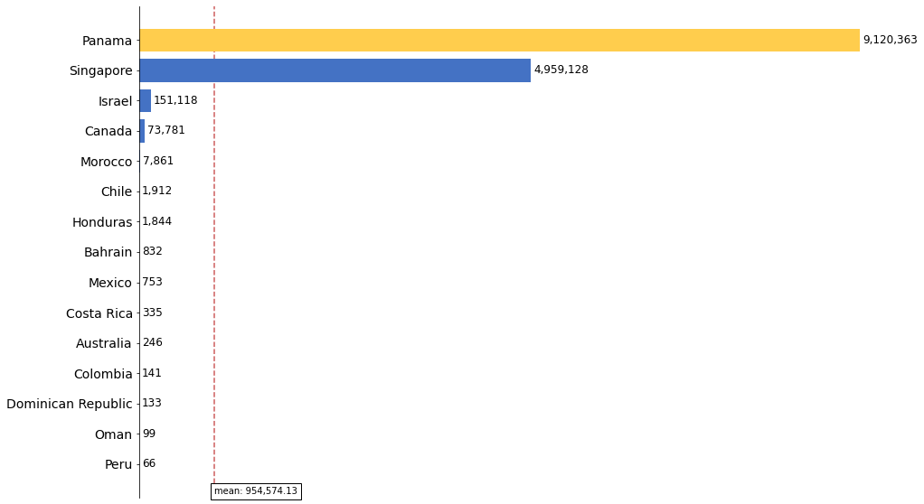

```python
mean_fta = df_usfta['count'].mean()

# figure size
fig, ax = plt.subplots(figsize=(15, 10))

# determine the color for the bars
bar_colors = ['#4472C4'] * len(df_usfta)
max_idx = df_usfta['count'].argmax()
bar_colors[max_idx] = '#ffcd4d'

# horizontal bar plot
works = plt.barh(df_usfta['country_name'],
                 df_usfta['count'],
                 height=0.75,
                 color=bar_colors)

# axis labels
ax.spines[['right', 'top', 'bottom']].set_visible(False)
ax.xaxis.set_visible(False)
formatter = tick.StrMethodFormatter('{x:,.0f}')
ax.xaxis.set_major_formatter(formatter)
ax.bar_label(works,
             labels=[f'{x:,.0f}' for x in df_usfta['count']],
             padding=3,
             color='#000000',
             fontsize=12,
             label_type='edge',
             fontweight='regular')
ax.yaxis.set_tick_params(labelsize=14)
ax.axvline(x=mean_fta, zorder=0, color='indianred', ls='--', lw=1.5)
ax.text(x=mean_fta, y=-1.0, s=f'mean: {mean_fta:,.2f}', ha='left',
        fontsize=10, bbox=dict(facecolor='white', edgecolor='black', ls='-'))

# Show Plot
plt.show()
```

As shown in Figure 4, and observed earlier in Figure 1, Panama and Singapore stand out as the two countries with the highest shipment counts among US FTA partners. Notably, their shipment numbers surpass the mean by a significant margin. In contrast, the remaining countries exhibit considerably lower shipment counts, with five countries (El Salvador, Guatemala, Jordan, Korea, and Nicaragua) recording no shipments at all from 2018 to 2020.

It is important to consider that various practical disadvantages associated with FTAs [(3. FTAs - advantages and disadvantages, n.d.)](https://www.dfat.gov.au/sites/default/files/Chapter3-2.pdf) may have influenced these shipment numbers for the other eighteen FTA partners. Factors such as the increasing complexity of the international trading system, which can raise transaction costs for businesses, resource-intensive negotiations, and the complex enforcement of different rules negotiated under these agreements, may have impacted the trade volume. These practical disadvantages highlight the challenges and complexities involved in navigating the international trade landscape and implementing effective trade agreements.

```python
df_nofta = df_all_countries[~df_all_countries['country_name'].isin(fta)]
```

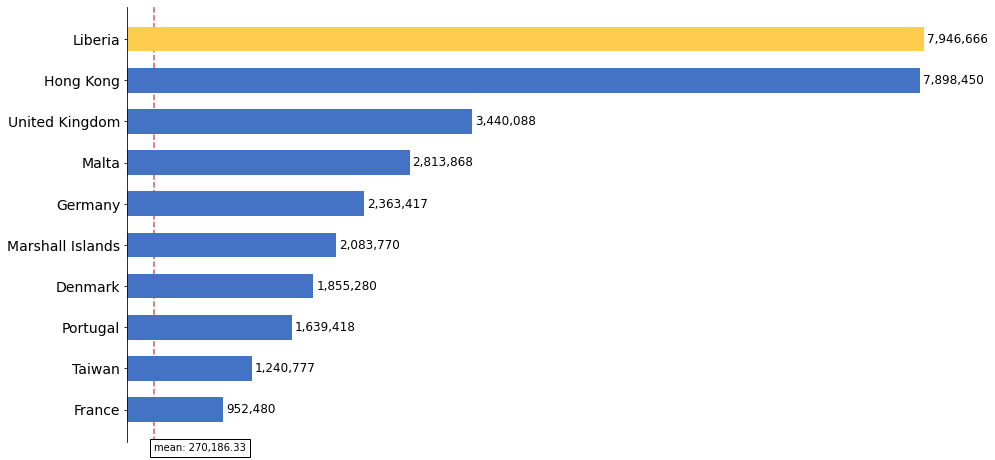

```python
mean_nofta = df_nofta['count'].mean()

# figure size
fig, ax = plt.subplots(figsize=(15, 8))

# determine the color for the bars
bar_colors = ['#4472C4'] * len(df_nofta)
max_idx = df_nofta['count'].argmax()
bar_colors[max_idx] = '#ffcd4d'

# horizontal bar plot
works = plt.barh(df_nofta['country_name'][-10:],
                 df_nofta['count'][-10:],
                 height=0.6,
                 color=bar_colors[-10:])

# axis labels
ax.spines[['right', 'top', 'bottom']].set_visible(False)
ax.xaxis.set_visible(False)
formatter = tick.StrMethodFormatter('{x:,.0f}')
ax.xaxis.set_major_formatter(formatter)
ax.bar_label(works,
             labels=[f'{x:,.0f}' for x in df_nofta['count'][-10:]],
             padding=3,
             color='#000000',
             fontsize=12,
             label_type='edge',
             fontweight='regular')
ax.yaxis.set_tick_params(labelsize=14)
ax.axvline(x=mean_nofta, zorder=0, color='indianred', ls='--', lw=1.5)
ax.text(x=mean_nofta, y=-1.0, s=f'mean: {mean_nofta:,.2f}', ha='left',
        fontsize=10, bbox=dict(facecolor='white', edgecolor='black', ls='-'))

# Show Plot
plt.show()
```

**Figure 5. Non-US FTA Partners with the Highest Number of Shipments.**  
*These are the ten non-US FTA partners with the highest recorded shipments from 2018 to 2020.*

Figure 5 reveals that eight of the countries listed entered the top ten countries with the highest number of shipments, as observed in Figure 1. Interestingly, these countries have managed to achieve significant shipment volumes without having an FTA with US. This suggests that they may be able to operate relatively free from the potential disadvantages mentioned earlier associated with FTAs.

One notable country in Figure 5 is the United Kingdom, which commenced its trade agreement negotiation with the United States in 2019 [(Broadbent, 2023)](https://www.csis.org/analysis/us-uk-trade-agreement-now-time). Given the UK's status as the largest European investor in the US and its position as the third-largest goods export market for the US (among non-FTA partners observed in Figure 5) or fifth-largest overall (among all countries observed in Figure 1), the initiation of trade agreement negotiations is not surprising. This trade agreement holds tremendous economic and strategic benefits for both economies [(Broadbent, 2023)](https://www.csis.org/analysis/us-uk-trade-agreement-now-time) and reflects their aspirations for closer trade ties. It is possible that other countries on this list may also pursue trade agreement negotiations, if not already underway, based on their shipment volumes to the US and the potential benefits they can derive from such agreements.

*Delays*

Next, we look at the shipment delays among shippers and countries exporting to US ports.

```python
delay_distri = pd.read_csv('data/delay_distri.csv')
```

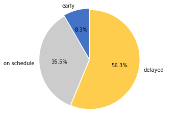

```python
# data
labels = delay_distri['is_delayed']
sizes = delay_distri['%']
colors = ['#CCCCCC', '#ffcd4d', '#4472C4']
explode = (0.01, 0.01, 0.025)

# create pie chart
fig, ax = plt.subplots()
ax.pie(sizes,
       labels=labels,
       colors=colors,
       autopct='%.1f%%',
       startangle=120,
       explode=explode)

# aspect ratio and title
ax.axis('equal')
# ax.set_title('Distribution of Delay Categories')

# show plot
plt.show()
```

**Figure 6. Distribution of Shipment Arrival Punctuality.**  
*Categorizing shipments as either delayed, early, or on schedule.*

Figure 6 highlights a concerning trend in the punctuality of shipments. More than half of the recorded shipments experienced delays or arrived late, indicating potential disruptions or inefficiencies in the supply chain. On the other hand, a mere 8 out of 100 shipments managed to arrive ahead of schedule. This emphasizes the importance of addressing the factors contributing to delays and implementing strategies to improve the timeliness of shipments.

```python
mean_delay = pd.read_csv('data/mean_delay.csv')
print(f'Shipments are delayed, on average, by {float(mean_delay.loc[0]):.0f} days.')
```

```
Shipments are delayed, on average, by 2 days.
```

```python
mean_order_count_shipper_delay_early = pd.read_csv('data/mean_order_count_shipper_delay_early.csv')
shippers_delays = mean_order_count_shipper_delay_early[
    mean_order_count_shipper_delay_early['count'] >= mean_order_count_shipper_delay_early['count'].mean()
]
shippers_delays = shippers_delays.sort_values('mean_delay', ascending=True)
```

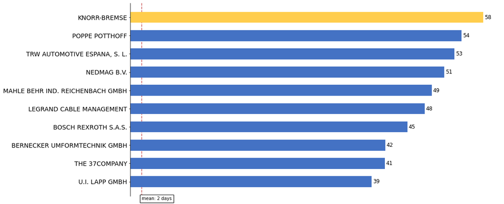

```python
# figure size
fig, ax = plt.subplots(figsize=(15, 8))

# determine the color for the bars
bar_colors = ['#4472C4'] * len(shippers_delays)
max_idx = shippers_delays['mean_delay'].argmax()
bar_colors[max_idx] = '#ffcd4d'

# horizontal bar plot
works = plt.barh(shippers_delays['shipper_party_name'][-10:],
                 shippers_delays['mean_delay'][-10:],
                 height=0.6,
                 color=bar_colors[-10:])

# axis labels
ax.spines[['right', 'top', 'bottom']].set_visible(False)
ax.xaxis.set_visible(False)
formatter = tick.StrMethodFormatter('{x:,.0f}')
ax.xaxis.set_major_formatter(formatter)
ax.bar_label(works,
             labels=[f'{x:,.0f}' for x in shippers_delays['mean_delay'][-10:]],
             padding=3,
             color='#000000',
             fontsize=12,
             label_type='edge',
             fontweight='regular')
ax.yaxis.set_tick_params(labelsize=14)
ax.axvline(x=float(mean_delay.loc[0]),
           zorder=0,
           color='indianred',
           ls='--',
           lw=1.5)
ax.text(x=float(mean_delay.loc[0]),
        y=-1.0,
        s=f'mean: {(float(mean_delay.loc[0])):,.0f} days',
        ha='left',
        fontsize=10,
        bbox=dict(facecolor='white', edgecolor='black', ls='-'))

# Show Plot
plt.show()
```

**Figure 7. Shippers with the Highest Shipment Delays.**  
*These are the top ten shippers with the greatest number of days of shipment delays.*

We conducted our investigation by excluding shippers with shipment counts below the average over the past three years. Among the remaining shippers, Figure 7 and Table 7 display the top performers in terms of shipment delays, far surpassing the average delay of two days. Notably, Knorr-Bremse recorded a delay of 58 days, followed by Poppe Potthoff at 54 days, and Negmag B.V. at 51 days. Other shippers on the list also experienced delays exceeding one month.

| Shipper | Country | Website |
| --- | --- | --- |
| Knorr-Bremse | Germany | https://www.knorr-bremse.com/en/ |
| Poppe-Potthoff | Germany | https://www.poppe-potthoff.com |
| TRW Automotive Espana, S.L. | Spain | https://www.trwaftermarket.com/es/ |
| Nedmag B.V. | The Netherlands | https://www.nedmag.com |
| MAHLE Behr Ind. Reichenbach GMBH | Germany | https://www.mahle.com/en/about-mahle/locations/5101.jsp |
| Legrand Cable Management | USA | https://www.legrand.us/wire-and-cable-management |
| Bosch Rexroth S.A.S. | France | https://www.boschrexroth.com/en/dc/ |
| Bernecker Umformtechnik GMBH | Germany | https://www.bernecker-group.com/de/ |
| The 37Company | The Netherlands |  |
| U.I. Lapp GMBH | Germany | https://www.lappgroup.com |

**Table 7. Shipper-Country Map.**  
*Mapping of the most delayed shippers to their country of origin.*

```python
df_delay_countries = df_all_countries.sort_values('mean_delay', ascending=True)
df_delay_countries = df_delay_countries[
    df_delay_countries['count'] >= df_delay_countries['count'].mean()
]
```

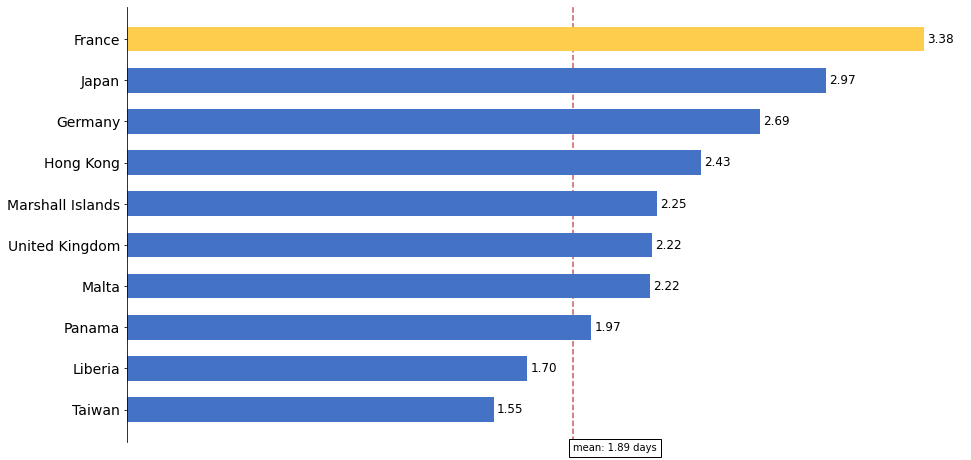

```python
# figure size
fig, ax = plt.subplots(figsize=(15, 8))

# determine the color for the bars
bar_colors = ['#4472C4'] * len(df_delay_countries)
max_idx = df_delay_countries['mean_delay'].argmax()
bar_colors[max_idx] = '#ffcd4d'

# horizontal bar plot
works = plt.barh(df_delay_countries['country_name'][-10:],
                 df_delay_countries['mean_delay'][-10:],
                 height=0.6,
                 color=bar_colors[-10:])

# axis labels
ax.spines[['right', 'top', 'bottom']].set_visible(False)
ax.xaxis.set_visible(False)
formatter = tick.StrMethodFormatter('{x:,.0f}')
ax.xaxis.set_major_formatter(formatter)
ax.bar_label(works,
             labels=[f'{x:,.2f}' for x in df_delay_countries['mean_delay'][-10:]],
             padding=3,
             color='#000000',
             fontsize=12,
             label_type='edge',
             fontweight='regular')
ax.yaxis.set_tick_params(labelsize=14)
ax.axvline(x=float(mean_delay.loc[0]),
           zorder=0,
           color='indianred',
           ls='--',
           lw=1.5)
ax.text(x=float(mean_delay.loc[0]),
        y=-1.0,
        s=f'mean: {(float(mean_delay.loc[0])):,.2f} days',
        ha='left',
        fontsize=10,
        bbox=dict(facecolor='white', edgecolor='black', ls='-'))

# Show Plot
plt.show()
```

**Figure 8. Countries with the Highest Shipment Delays.**  
*These are the top ten countries associated with the greatest number of days of shipment delays.*

Considering the significant delays experienced by German businesses, it may be beneficial for Germany to review its shipment policies and processes to address the issue. The average delay of 2.69 days for Germany as a whole highlights the potential impact on the overall supply chain, posing risks for individual businesses. France, Japan, and the others in the Top 10 could also benefit from similar evaluations to improve their shipment efficiency and reduce delays. Addressing these delays is crucial to maintaining a smooth and efficient supply chain, as delays can disrupt operations and impact customer satisfaction.

```python
df_delay_all_fta = df_all_countries[df_all_countries[
    'country_name'].isin(fta)]
df_delay_all_fta = df_delay_all_fta.sort_values('mean_delay', ascending=True)
```

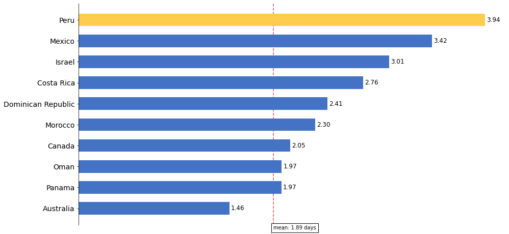

```python
# figure size
fig, ax = plt.subplots(figsize=(15, 8))

# determine the color for the bars
bar_colors = ['#4472C4'] * len(df_delay_all_fta)
max_idx = df_delay_all_fta['mean_delay'].argmax()
bar_colors[max_idx] = '#ffcd4d'

# horizontal bar plot
works = plt.barh(df_delay_all_fta['country_name'][-10:],
                 df_delay_all_fta['mean_delay'][-10:],
                 height=0.6,
                 color=bar_colors[-10:])

# axis labels
ax.spines[['right', 'top', 'bottom']].set_visible(False)
ax.xaxis.set_visible(False)
formatter = tick.StrMethodFormatter('{x:,.0f}')
ax.xaxis.set_major_formatter(formatter)
ax.bar_label(works,
             labels=[f'{x:,.2f}' for x in df_delay_all_fta['mean_delay'][-10:]],
             padding=3,
             color='#000000',
             fontsize=12,
             label_type='edge',
             fontweight='regular')
ax.yaxis.set_tick_params(labelsize=14)
ax.axvline(x=float(mean_delay.loc[0]),
           zorder=0,
           color='indianred',
           ls='--',
           lw=1.5)
ax.text(x=float(mean_delay.loc[0]),
        y=-1.0,
        s=f'mean: {(float(mean_delay.loc[0])):,.2f} days',
        ha='left',
        fontsize=10,
        bbox=dict(facecolor='white', edgecolor='black', ls='-'))

# Show Plot
plt.show()
```

**Figure 9. US FTA Partners with the Highest Shipment Delays.**  
*These are the top ten US FTA partners associated with the greatest number of days of shipment delays.*

In this analysis of the US FTA partners and the arrival of shipments associated with them, we considered all countries without setting a threshold. This allows us to gain insights into the shipment performance of each partner country.

One notable finding is that Peru, despite having the lowest number of shipments among the countries with an active FTA with the US (66 shipments), has an average delay of four days, which is double the mean delay of the entire dataset. This suggests that Peru may need to revisit not only its FTA rules with the US but also its shipment policies to address the delays and improve the efficiency of its supply chain.

```python
df_delay_allnot_fta = df_all_countries[~df_all_countries['country_name'].isin(fta)]
df_delay_allnot_fta = df_delay_allnot_fta.sort_values('mean_delay', ascending=True)
```

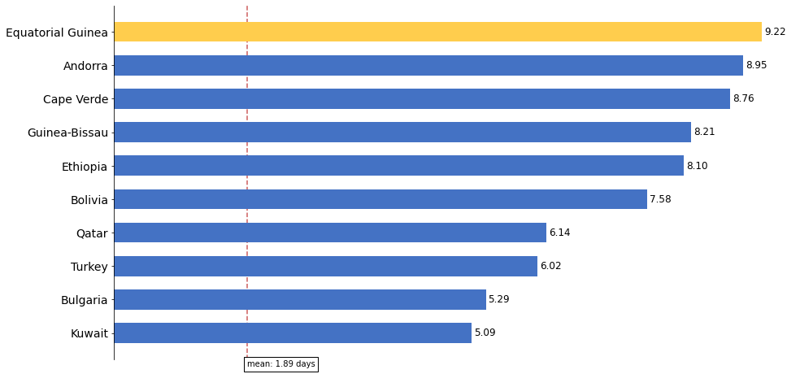

```python
# figure size
fig, ax = plt.subplots(figsize=(15, 8))

# determine the color for the bars
bar_colors = ['#4472C4'] * len(df_delay_allnot_fta)
max_idx = df_delay_allnot_fta['mean_delay'].argmax()
bar_colors[max_idx] = '#ffcd4d'

# horizontal bar plot
works = plt.barh(df_delay_allnot_fta['country_name'][-10:],
                 df_delay_allnot_fta['mean_delay'][-10:],
                 height=0.6,
                 color=bar_colors[-10:])

# axis labels
ax.spines[['right', 'top', 'bottom']].set_visible(False)
ax.xaxis.set_visible(False)
formatter = tick.StrMethodFormatter('{x:,.0f}')
ax.xaxis.set_major_formatter(formatter)
ax.bar_label(works,
             labels=[f'{x:,.2f}' for x in df_delay_allnot_fta['mean_delay'][-10:]],
             padding=3,
             color='#000000',
             fontsize=12,
             label_type='edge',
             fontweight='regular')
ax.yaxis.set_tick_params(labelsize=14)
ax.axvline(x=float(mean_delay.loc[0]),
           zorder=0,
           color='indianred',
           ls='--',
           lw=1.5)
ax.text(x=float(mean_delay.loc[0]),
        y=-1.0,
        s=f'mean: {(float(mean_delay.loc[0])):,.2f} days',
        ha='left',
        fontsize=10,
        bbox=dict(facecolor='white', edgecolor='black', ls='-'))

# Show Plot
plt.show()
```

**Figure 10. Non-US FTA Partners with the Highest Shipment Delays.**  
*These are the top ten non-US FTA partners associated with the greatest number of days of shipment delays.*

The ten non-US partners with the highest shipment delays recorded an average delay of at least five days for their shipments, as seen in Figure 10. While these countries are not bound by the rules and regulations of a trade agreement, it is important for them to examine their shipment time management practices as efficient and timely shipments are crucial for businesses to maintain a competitive edge in the global market. The significant delays observed in these countries pose risks to individual businesses and can potentially impact customer satisfaction.

Overall, it is important to note that delayed shipments may not always be attributed solely to the actions of the shippers themselves. There are various external factors that can contribute to delays, which are often beyond the control [(Freightos, n.d.)](https://www.freightos.com/freight-resources/reasons-causes-of-shipment-delays/) of the shippers.

Global events and disruptions, such as natural disasters, political unrest, or pandemics, can have a significant impact on the movement of goods and lead to shipment delays. These unforeseen circumstances can disrupt supply chains, cause port congestion, and result in logistical challenges.

Port congestion and traffic are common issues that affect the shipping industry. Limited infrastructure, inadequate port capacity, or inefficient operations can lead to delays in the handling and processing of shipments. These challenges can arise from the complex relationship between shipping lines and port authorities, which need to be effectively managed to ensure smooth operations.

Unpredictable weather conditions, particularly for freights navigating through tumultuous and unstable bodies of water, can also contribute to shipment delays. Adverse weather events such as storms, hurricanes, or heavy fog can disrupt maritime transportation and force vessels to alter their routes or wait for safer conditions before proceeding.

While shippers play a crucial role in ensuring timely shipments, it is essential to consider these external factors that can impact the delivery timeline. Collaborative efforts among shippers, carriers, port authorities, and other stakeholders are necessary to mitigate the effects of these challenges and find solutions to minimize delays.

*Trends*

The outbreak of the COVID-19 pandemic in 2020 had far-reaching implications for various industries worldwide, including international trade and shipping. The implementation of lockdowns, travel restrictions, and social distancing measures significantly disrupted global supply chains and logistics networks.

In examining the trends in shipment counts from 2018 to 2020, we have a unique opportunity to explore the impact of the global pandemic that occurred in 2020, leveraging historical data from the preceding years. Specifically, we are interested in investigating the effect of COVID-19 on ocean freights and shipment deliveries.

**Shipments**

```python
shipment_distri_year_month = pd.read_csv('data/delay_early_distri_year_month.csv')
```

```python
shipment_trend = shipment_distri_year_month.pivot(index='estimated_year_month', columns='is_delayed', values='count')
shipment_trend['total'] = shipment_trend['delayed'] + shipment_trend['on schedule'] + shipment_trend['early']
shipment_trend = shipment_trend.drop(['2020-10', '2020-11', '2020-12'], axis=0).reset_index()
# shipment_trend
```

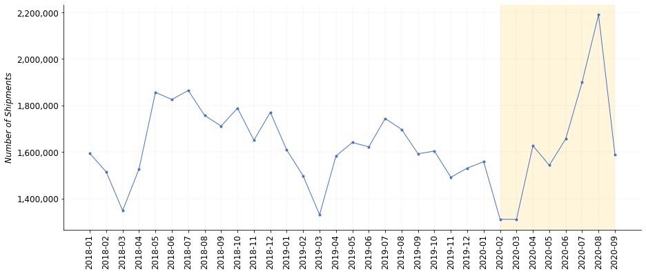

```python
# figure size
fig, ax = plt.subplots(figsize=(15, 6))

# plot line
ax.plot(shipment_trend['estimated_year_month'].tolist(),
        shipment_trend['total'].tolist(),
        marker='o',
        markersize=3,
        color='#4472C4',
        linestyle='-',
        linewidth=1)

mean_shipment = shipment_trend['total'].mean()

# format chart
formatter = tick.FuncFormatter(lambda x, p: format(int(x), ','))
ax.yaxis.set_major_formatter(formatter)
ax.axvspan('2020-02', shipment_trend['estimated_year_month'].max(), facecolor='#ffcd4d', alpha=0.2)
ax.spines[['right', 'top']].set_visible(False)
ax.xaxis.set_tick_params(labelsize=12, rotation=90)
ax.yaxis.set_tick_params(labelsize=12)

# label
# ax.set_xlabel('2018 to 2020', fontsize=12)
ax.set_ylabel('Number of Shipments', fontsize=12, fontstyle='italic')

# show plot
plt.grid(True, linewidth=0.1)
plt.show()
```

**Figure 11. Trend in Total Monthly Shipments.**  
*Illustration of the trend in total monthly shipments from January 2018 to September 2020.*

As we examine Figure 11, we can clearly observe the impact of the COVID-19 pandemic on the shipment counts. The onset of the pandemic, highlighted by the prominent decline in February and March of 2020, brought about a significant disruption to global operations, affecting almost all industries except essential services such as healthcare. The shipping industry was no exception and experienced a considerable slowdown during the initial lockdown period.

The strict restrictions and containment measures implemented to curb the spread of the virus resulted in temporary shutdowns of manufacturing facilities, reduced consumer demand, and logistical challenges. These factors contributed to the decline in shipment counts during the early months of the pandemic.

However, as the months progressed and governments began to gradually ease restrictions, we can observe a notable spike in shipment counts from June to August. This increase can be attributed to the resumption of economic activities and the gradual reopening of businesses in many parts of the world. As industries adapted to the new normal and implemented safety protocols, the shipping industry also saw a recovery in terms of shipment volumes.

It is important to note that the sudden drop in shipment counts in September is due to the limitation of available data, as the dataset only extends up to that period. Therefore, the decline does not necessarily reflect an actual decrease in shipments but rather a data limitation.

Additionally, the spike in shipment counts from June to August may also be influenced by the upgrading of logistics services during the pandemic crisis. As logistics services, including the shipping industry, were deemed essential for the movement of goods without risking infection among people, efforts were made to enhance these services. This could have led to an increased demand for logistics and shipping, resulting in the observed spike in shipment counts during that period.

**Shipments of US FTA Partners**

```python
all_countries = pd.read_csv('data/all_country_yearmonth_trend-2.csv')
if all_countries.index.duplicated().any():
    all_countries = all_countries.reset_index()
```

```python
country_trend = all_countries.pivot_table(index='actual_year_month', columns='country_name', values='count', aggfunc='sum')
```

```python
fta_3_columns = df_usfta['country_name'][-3:].tolist()
```

```python
fta_trend = country_trend[fta_3_columns].reset_index()
```

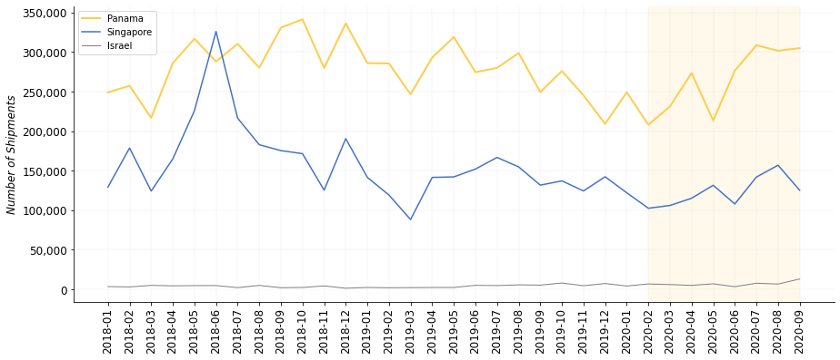

```python
# figure size
fig, ax = plt.subplots(figsize=(15, 6))

# plot line : early
ax.plot(fta_trend['actual_year_month'].tolist(),
        fta_trend['Panama'].tolist(),
#        marker='o',
#        markersize=3,
        color='#ffcd4d',
        linestyle='-',
        linewidth=2,
        label='Panama')

# plot line : delayed
ax.plot(fta_trend['actual_year_month'].tolist(),
        fta_trend['Singapore'].tolist(),
#        marker='o',
#        markersize=3,
        color='#4472C4',
        linestyle='-',
        linewidth=1.5,
        label='Singapore')

# plot line : on schedule
ax.plot(fta_trend['actual_year_month'].tolist(),
        fta_trend['Israel'].tolist(),
#        marker='o',
#        markersize=3,
        color='#808080',
        linestyle='-',
        linewidth=1,
        label='Israel')

# format chart
formatter = tick.FuncFormatter(lambda x, p: format(int(x), ','))
ax.yaxis.set_major_formatter(formatter)
ax.axvspan('2020-02', shipment_trend['estimated_year_month'].max(), facecolor='#ffcd4d', alpha=0.1)
ax.spines[['right', 'top']].set_visible(False)
ax.xaxis.set_tick_params(labelsize=12, rotation=90)
ax.yaxis.set_tick_params(labelsize=12)

# label
# ax.set_xlabel('2018 to 2020', fontsize=12)
ax.set_ylabel('Number of Shipments', fontsize=12, fontstyle='italic')

# Legend
plt.legend(loc='upper left')

# show plot
plt.grid(True, linewidth=0.1)
plt.show()
```

**Figure 12. Trend in Total Monthly Shipments of US FTA Partners.**  
*These are the monthly shipment trend of US FTA partners with the highest number of shipments.*

We can observe in Figure 12 some interesting trends in shipment counts at the onset of the COVID-19 pandemic. Contrary to expectations, both Panama and Singapore experienced a slight increase in shipments during this period, while Israel maintained a relatively consistent monthly shipment trend.

The increase in shipments for Panama and Singapore during the early months of the pandemic could be attributed to several factors. One possible explanation is that these countries, being major shipping hubs and international trade centers, continued to play a crucial role in facilitating global trade even amid the pandemic. As other regions and countries faced disruptions and restrictions, businesses may have relied more on these well-established shipping routes and logistics networks to ensure the flow of essential goods.

Another factor to consider is the specific industries and goods that these countries specialize in. Panama, for instance, is known for its strategic location and the Panama Canal, which serves as a vital trade artery connecting the Atlantic and Pacific Oceans. The canal's efficiency and importance for international shipping could have contributed to the sustained shipment activity in Panama during the early months of the pandemic.

Similarly, Singapore, as a global financial and logistics hub, has a well-developed infrastructure and strong connectivity with international markets. This could have allowed the country to maintain a relatively stable level of shipments, especially for essential goods and commodities.

**Shipments of Non-US FTA Partners**

```python
nofta_3_columns = df_nofta['country_name'][-3:].tolist()
```

```python
nofta_trend = country_trend[nofta_3_columns].reset_index()
```

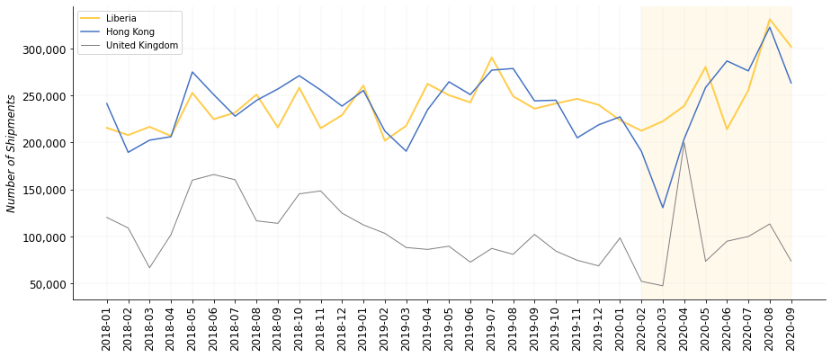

```python
# figure size
fig, ax = plt.subplots(figsize=(15, 6))

# plot line : early
ax.plot(nofta_trend['actual_year_month'].tolist(),
        nofta_trend['Liberia'].tolist(),
#        marker='o',
#        markersize=3,
        color='#ffcd4d',
        linestyle='-',
        linewidth=2,
        label='Liberia')

# plot line : delayed
ax.plot(nofta_trend['actual_year_month'].tolist(),
        nofta_trend['Hong Kong'].tolist(),
#        marker='o',
#        markersize=3,
        color='#4472C4',
        linestyle='-',
        linewidth=1.5,
        label='Hong Kong')

# plot line : on schedule
ax.plot(nofta_trend['actual_year_month'].tolist(),
        nofta_trend['United Kingdom'].tolist(),
#        marker='o',
#        markersize=3,
        color='#808080',
        linestyle='-',
        linewidth=1,
        label='United Kingdom')

# format chart
formatter = tick.FuncFormatter(lambda x, p: format(int(x), ','))
ax.yaxis.set_major_formatter(formatter)
ax.axvspan('2020-02', shipment_trend['estimated_year_month'].max(), facecolor='#ffcd4d', alpha=0.1)
ax.spines[['right', 'top']].set_visible(False)
ax.xaxis.set_tick_params(labelsize=12, rotation=90)
ax.yaxis.set_tick_params(labelsize=12)

# label
# ax.set_xlabel('2018 to 2020', fontsize=12)
ax.set_ylabel('Number of Shipments', fontsize=12, fontstyle='italic')

# Legend
plt.legend(loc='upper left')

# show plot
plt.grid(True, linewidth=0.1)
plt.show()
```

**Figure 13. Trend in Total Monthly Shipments of Non-US FTA Partners.**  
*These are the monthly shipment trend of non-US FTA partners with the highest number of shipments.*

Figure 13 provides further insights into the impact of the COVID-19 pandemic on shipment counts, showcasing the gradual recovery and fluctuations in the months following the onset of the crisis. The graph illustrates the overall trend of shipment counts for various countries during this period.

One notable observation is the spike in UK shipments in April 2020, despite the challenging circumstances and strict restrictions in place. This surge in shipments highlights the UK's crucial role in the global supply chain, particularly in serving the US markets. Despite the significant disruptions caused by the pandemic, the UK was able to maintain its supply chain operations and deliver goods to the US, underscoring its resilience and importance as a trading partner.

Moreover, like Panama and Singapore, Hong Kong demonstrated resilience and adaptability in navigating the challenges posed by the global crisis. The graph showcases a significant increase in shipments after the initial impact of the pandemic in March 2020, highlighting Hong Kong's importance in the US market landscape.

*Disruptions*

Aside from the significant impact of the COVID-19 pandemic on ocean freights and shipments, recent events have also brought disruptions to global trade. We examine two of these events below.

**Russo-Ukrainian War**

```python
ruw = ['Russia', 'Ukraine']
```

```python
df_ruw = country_trend[ruw].reset_index()
df_ruw['Russia'] = df_ruw['Russia'].fillna(method='bfill')
```

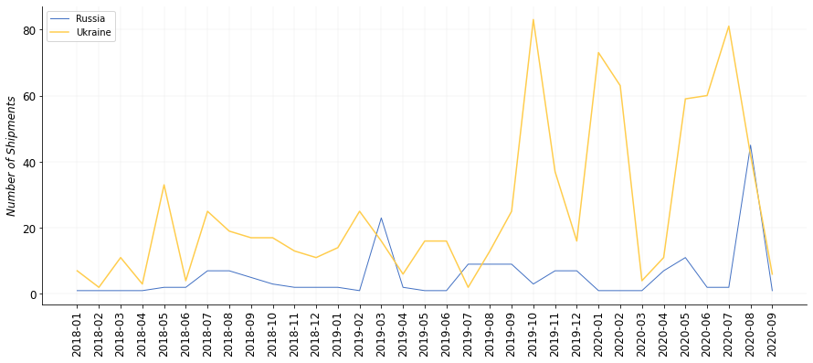

```python
# figure size
fig, ax = plt.subplots(figsize=(15, 6))

# plot line : early
ax.plot(df_ruw['actual_year_month'].tolist(),
        df_ruw['Russia'].tolist(),
#        marker='o',
#        markersize=3,
        color='#4472C4',
        linestyle='-',
        linewidth=1,
        label='Russia')

# plot line : delayed
ax.plot(df_ruw['actual_year_month'].tolist(),
        df_ruw['Ukraine'].tolist(),
#        marker='o',
#        markersize=3,
        color='#ffcd4d',
        linestyle='-',
        linewidth=1.5,
        label='Ukraine')

# # plot line : on schedule
# ax.plot(shipment_trend['estimated_year_month'].tolist(),
#         shipment_trend['on schedule'].tolist(),
# #        marker='o',
# #        markersize=3,
#         color='#808080',
#         linestyle='-',
#         linewidth=1,
#         label='on schedule')

# format chart
formatter = tick.FuncFormatter(lambda x, p: format(int(x), ','))
ax.yaxis.set_major_formatter(formatter)
# .axvspan('2020-02', shipment_trend['estimated_year_month'].max(), facecolor='#ffcd4d', alpha=0.1)
ax.spines[['right', 'top']].set_visible(False)
ax.xaxis.set_tick_params(labelsize=12, rotation=90)
ax.yaxis.set_tick_params(labelsize=12)

# label
# ax.set_xlabel('2018 to 2020', fontsize=12)
ax.set_ylabel('Number of Shipments', fontsize=12, fontstyle='italic')

# Legend
plt.legend(loc='upper left')

# show plot
plt.grid(True, linewidth=0.1)
plt.show()
```

The Russo-Ukrainian war, which escalated in February 2022 with the invasion of Ukraine by Russia [(Financial Times, n.d.)](https://www.ft.com/content/4351d5b0-0888-4b47-9368-6bc4dfbccbf5), has had significant implications for the trade dynamics between the two countries and their relationships with the United States. It is important to note that the origins of this conflict can be traced back to 2014 [(Congressional Research Service, 2023)](https://crsreports.congress.gov/product/pdf/IF/IF12277), when tensions between Russia and Ukraine began to rise.

Additionally, the strained relationship between Russia and the US may have influenced the trade dynamics. The political and diplomatic tensions resulting from the conflict have likely affected business confidence and led to a decrease in trade activities. Furthermore, the impact of the conflict on Russia's economy and infrastructure may have hindered its ability to engage in international trade.

On the other hand, the relationship between Ukraine and the US, particularly in the context of the conflict with Russia, may have contributed to a greater number of shipments to the US. The US has been supportive of Ukraine throughout the crisis [(U.S. Embassy Kiev, 2023)](https://ua.usembassy.gov/treasury-secretry-yellen-delivers-remarks-on-u-s-support-for-ukraine/), providing economic and military assistance. This support, combined with the strategic importance of Ukraine in the region, may have resulted in increased trade flows between Ukraine and the US.

**Disclaimer:** *The color scheme used in this project, including any resemblance to the flag colors of Ukraine or any other country, is purely coincidental and has no political or ideological significance.*

**Beirut Port Explosion**

```python
lebanon = country_trend['Lebanon']
```

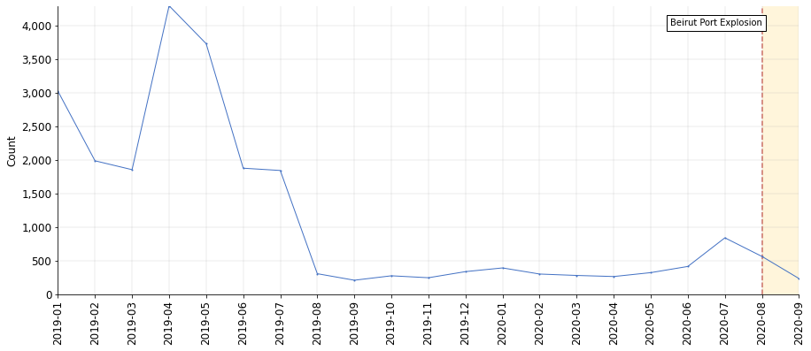

```python
# figure size
fig, ax = plt.subplots(figsize=(15, 6))

# plot line
ax.plot(lebanon.index.tolist(),
        lebanon.tolist(),
        marker='o',
        markersize=1,
        color='#4472C4',
        linestyle='-',
        linewidth=1)

# format chart
formatter = tick.FuncFormatter(lambda x, p: format(int(x), ','))
ax.yaxis.set_major_formatter(formatter)
ax.axvspan('2020-08', '2020-09', facecolor='#ffcd4d', alpha=0.2)
ax.spines[['right', 'top']].set_visible(False)
ax.xaxis.set_tick_params(labelsize=12, rotation=90)
ax.yaxis.set_tick_params(labelsize=12)

# label
# ax.set_xlabel('2018 to 2020', fontsize=12)
ax.set_ylabel('Count', fontsize=12)


ax.axvline('2020-08',
           zorder=0,
           color='indianred',
           ls='--',
           lw=1.5)
ax.text('2020-08',
        y=4_000,
        s=f'Beirut Port Explosion',
        ha='right',
        fontsize=10,
        bbox=dict(facecolor='white', edgecolor='black', ls='-'))


# show plot
plt.xlim(['2019-01', '2020-09'])
plt.ylim([0, max(lebanon.tolist())])
plt.grid(True, linewidth=0.25)
plt.show()
```

**Figure 15. Trend in Lebanon's Monthly Shipment.**  
*Illustration of Lebanon's shipment trend before and after the Beirut Port Explosion.*

As depicted in Figure 15, the available data does not provide conclusive evidence regarding the trend of shipments from Lebanon following the devastating Beirut Port Explosion in August 2020 [(Chulov, 2021)](https://www.theguardian.com/world/2021/aug/04/a-year-on-from-beruit-explosion-scars-and-questions-remain). While there is a noticeable decline in the number of shipments in September 2020, it is important to note that this is limited to the coverage of our available data. To gain a comprehensive understanding of the trend, further data from subsequent months would be required. The impact of the Beirut Port Explosion on Lebanon's shipment patterns warrants continued analysis and examination.

# Conclusion

*Case Study*

This `Shipments` section highlights the complex dynamics of international trade and emphasizes the significance of trade agreements, taxation policies, and strategic partnerships in shaping shipment volumes between countries.

The presence of Free Trade Agreements has influenced shipment volumes, with Panama and Singapore leading among the US FTA partners. However, practical disadvantages associated with FTAs may have affected trade volumes for other partner countries. Interestingly, several countries achieved significant shipment volumes without an FTA, indicating that they operate relatively free from potential disadvantages.

Next, the `Delays` section reveals concerning trends, with more than half of recorded shipments experiencing delays. The top performers in terms of shipment delays predominantly consist of German companies, indicating the need for Germany to review its shipment policies and processes. Other countries, including France, Japan, and the US FTA partners, also face challenges in ensuring timely deliveries and should evaluate their shipment efficiency.

Furthermore, as discussed in the `Trends` section, the COVID-19 pandemic had a profound impact on global shipping and trade, resulting in disruptions and fluctuations in shipment counts. The initial months of the pandemic saw a significant decline in shipments as lockdowns and restrictions affected manufacturing, consumer demand, and logistics - ocean freights and shipment deliveries included. However, as economies gradually reopened and adapted to the new normal, there was a recovery in shipment volumes. Certain countries, such as Panama, Singapore, the UK, and Hong Kong, demonstrated resilience and played crucial roles in facilitating global trade during this challenging period.

Lastly, the `Disruptions` section highlights the geopolitical risks and local crises such as the Russo-Ukrainian war and the Beirut Port Explosion that can significantly affect the shipping industry. It is crucial for stakeholders to stay vigilant and adapt their strategies to mitigate the impact of such disruptions.

*Technical*

Leveraging cloud computing, particularly on AWS, offers significant advantages for big data analytics. It enables efficient processing of large volumes of data, facilitates integration with advanced analytics tools, and provides valuable insights for data-driven decision-making. However, careful resource management, consideration of dataset size and characteristics, and attention to security and compliance are essential.

The conversion of files from CSV to Parquet format proved highly beneficial in terms of space savings and faster processing. However, it may not be suitable for small datasets or scenarios involving high write frequency. Parquet's compatibility and suitability should be evaluated based on specific use cases and data requirements.

Moreover, AWS EMR provides flexibility and speed for big data processing, simplifying analysis compared to traditional servers. Scalability and integration with other AWS services enhance data ingestion and analysis. However, expertise in managing EMR clusters and optimizing resource configurations [(NetApp, n.d.)](https://bluexp.netapp.com/blog/optimizing-aws-emr-best-practices) is necessary to ensure cost-effectiveness and efficient performance.

Lastly, AWS Data Exchange offers a wide range of free datasets, simplifying data transfer between repositories. Users should exercise caution when subscribing to datasets, as some may come with associated costs. Understanding pricing information and evaluating the value and relevance of each dataset helps manage expenses effectively.

# Recommendations

*Case Study*

- To **further enhance trade volumes**, countries with low shipment numbers, such as Peru, should reassess their trade and taxation policies. It is also important for countries to consider the advantages and disadvantages of FTAs and explore alternative trade strategies to foster growth and strengthen trade relationships with the United States. Moreover, the ongoing trade agreement negotiation between the United Kingdom and the US reflects the UK's significant investment and export market potential. This negotiation could inspire other countries to pursue similar agreements based on their shipment volumes and potential benefits.
- To **improve shipment efficiency and address delays** in the supply chain, it is important to consider unforeseen disruptions that can impact the movement of goods. These disruptions include natural disasters, political unrest, and pandemics. To mitigate the effects of such events, it is recommended to develop robust contingency plans, diversify transportation routes, and maintain effective communication channels. By preparing for unforeseen disruptions, countries and companies can minimize delays and ensure a more reliable supply chain.
- To address the challenges brought by the COVID-19 pandemic and **improve the resilience and efficiency** of the global shipping industry, it is recommended to enhance supply chain resilience, embrace digitalization and automation, strengthen collaboration and communication among stakeholders, and invest in infrastructure and logistics capabilities. These measures will enable countries and companies to better adapt to disruptions.
- To **foster a resilient shipping industry amidst recent disruptions**, businesses should assess geopolitical risks, diversify trade partners, enhance supply chain visibility, strengthen crisis management capabilities, and collaborate with industry associations. These measures will help navigate challenges, ensure stability, and build a more adaptive and resilient shipping sector.

*Technical*

To optimize cost efficiency and enhance analysis capabilities, it is recommended to adjust cluster sizes based on the dataset's actual size. This ensures resources are right-sized, minimizing wastage and resulting in cost savings. Additionally, leveraging machine learning techniques, such as time series analysis, can enable accurate shipment forecasting, allowing for better planning and decision-making in logistics operations.

In constructing an ETL pipeline in AWS for data processing and automation, consider utilizing AWS Glue [(aws, n.d.)](https://docs.aws.amazon.com/glue/latest/dg/aws-glue-programming-python.html) [(Bok, 2020)](https://towardsdatascience.com/aws-glue-101-all-you-need-to-know-with-a-real-world-example-f34af17b782f), a fully managed ETL service. AWS Glue simplifies the process by offering a serverless environment for data extraction, transformation, and loading. This eliminates the need for extensive Python scripting, reduces operational overhead, and enables efficient data processing and automation at scale.

To enhance the analysis of the dataset for shippers and ports, incorporate Natural Language Processing (NLP) and geospatial analysis techniques [(Hu & Adams, n.d.)](https://www.acsu.buffalo.edu/~yhu42/papers/2020_BGD_DataFromText.pdf) [(Sohail, 2020)](https://medium.com/geoai/geospatial-natural-language-processing-ee3fc6ea6939). By leveraging NLP, addresses can be interpreted, and relevant information such as city, state, and country can be accurately extracted and tagged. This enriched data provides deeper insights, enabling more granular analysis and a better understanding of the geographical distribution of shipments, facilitating improved decision-making for shippers and ports.

By implementing these strategies, businesses can achieve cost savings, accurate forecasting, streamlined data processing, and enhanced analysis capabilities in the context of shipments and logistics [(Tsolaki, et. al., 2022)](https://www.sciencedirect.com/science/article/pii/S2405959522000200).

*Further Studies*

- Expand the dataset's timeline coverage to provide a broader historical context. While the 2018-2020 data offered valuable insights, including a longer timeframe would facilitate the analysis of disruptions and current events that are time-dependent or sensitive. This would enable a more comprehensive understanding of trade dynamics and their evolution over time.
- Investigate the categories of imported/exported goods and analyze the variations in tariffs imposed on different types of goods. Mapping these goods as specialized products for shippers and countries would reveal how they impact overall trade, agreement negotiations, and supply chain operations. This analysis would provide valuable insights into the composition and dynamics of trade flows.
- Consider expanding the scope of analysis beyond ocean freights to include other freight modes such as land and air shipments, or combinations of modes. This broader perspective would offer a more comprehensive understanding of the transportation landscape and reveal unique insights into the interplay between different modes of transportation in global trade.
- Examine the correlation between shipment figures in the dataset and GDP to assess the impact of trade on economic growth. Understanding how trade volumes affect GDP can inform policy decisions and provide insights into the economic benefits derived from international trade. This analysis would help policymakers gauge the effectiveness of trade policies and their implications for economic development.

# References

aws. (n.d.). *Program AWS Glue ETL scripts in PySpark*. https://docs.aws.amazon.com/glue/latest/dg/aws-glue-programming-python.html

Bok, K. (2020, Nov 3). AWS Glue 101: All you need to know with a full walk-through. *Towards Data Science*. https://towardsdatascience.com/aws-glue-101-all-you-need-to-know-with-a-real-world-example-f34af17b782f

Broadbent, M. (2023, Jan 23). U.S.-UK Trade Agreement: Now Is The Time. *CSIS*. https://www.csis.org/analysis/us-uk-trade-agreement-now-time

Chulov, M. (2021, Aug 4). A year on from Beirut explosion, scars and questions remain. *The Guardian*. https://www.theguardian.com/world/2021/aug/04/a-year-on-from-beruit-explosion-scars-and-questions-remain

Congressional Research Service. (n.d.). *The Economic Impact of Russia Sanctions.* https://crsreports.congress.gov/product/pdf/IF/IF12092

Congressional Research Service. (n.d.). *Russia's War on Ukraine: U.S. Policy and the Role of Congress*. https://crsreports.congress.gov/product/pdf/IF/IF12277

Enigma. (n.d.). US Imports - Automated Manifest System (AMS) Shipments 2018-2020. *aws marketplace*. https://aws.amazon.com/marketplace/pp/prodview-stk4wn3mbhx24#offers

Financial Times. (n.d.). *Russia's invasion of Ukraine in maps - latest updates*. https://www.ft.com/content/4351d5b0-0888-4b47-9368-6bc4dfbccbf5

Freightos. (n.d.) *Top Reasons Your Shipment Is Delayed: Trucking Issues, Incorrect Documentation & More*. https://www.freightos.com/freight-resources/reasons-causes-of-shipment-delays/

Hayes, A. (2022, Dec 28). Bilaterial Tax Agreement. *Investopedia*. https://www.investopedia.com/terms/b/bilateral-tax-agreement.asp

Hu, Y. & Adams, B. (n.d.). Chapter 0 - Harvesting Big Geospatial Data from Natural Language Texts. https://www.acsu.buffalo.edu/~yhu42/papers/2020_BGD_DataFromText.pdf

International Trade Administration. (n.d.). *Hong Kong - Country Commercial Guide.* https://www.trade.gov/country-commercial-guides/liberia-trade-agreements

International Trade Administration. (n.d.). *Liberia - Country Commercial Guide.* https://www.trade.gov/knowledge-product/hong-kong-macau-trade-agreements

International Trade Administration. (n.d.). *Panama - Country Commercial Guide.* https://www.trade.gov/country-commercial-guides/panama-trade-agreements

International Trade Administration. (n.d.). *Peru - Country Commercial Guide.* https://www.trade.gov/country-commercial-guides/peru-trade-agreements

International Trade Administration. (n.d.). *U.S. - CAFTA-DR Free Trade Agreement.* https://www.trade.gov/us-cafta-dr-free-trade-agreement

NetApp. (n.d.). *Best Practices and Tips for Optimizing Amazon Elastic MapReduce*. https://bluexp.netapp.com/blog/optimizing-aws-emr-best-practices

Shulga, N. (2023, Jun). Protectionism could make the world less resilient, more unequal, and more conflict-prone. *International Monetary Fund*. https://www.imf.org/en/Publications/fandd/issues/2023/06/growing-threats-to-global-trade-goldberg-reed

Sohail, S. (2020, Apr 28). Geosparial Natural Language Processing. *Medium*. https://medium.com/geoai/geospatial-natural-language-processing-ee3fc6ea6939

Tsolaki, K., et. al. (2022 Feb). Utilizing machine learning on freight transportation and logistics applications: A review. *ICT Express*. https://doi.org/10.1016/j.icte.2022.02.001

U.S. Embassy in Ukraine. (2023, Feb 27). *Treasury Secretry Yellen Delivers Remarks on U.S. support for Ukraine*. https://ua.usembassy.gov/treasury-secretry-yellen-delivers-remarks-on-u-s-support-for-ukraine/

Williams, G. (2023, May 19). What Is a Global Supply Chain? *Business Class.* https://www.americanexpress.com/en-us/business/trends-and-insights/articles/what-is-a-global-supply-chain/

York, E. (2018, Jun 27). The Impact of Trade and Tariffs on the United States. *Tax Foundation*. https://taxfoundation.org/impact-of-tariffs-free-trade/

"3. FTAs - advantages and disadvantages." (n.d.) An Australia–USA Free Trade Agreement: Issues and Implications. https://www.dfat.gov.au/sites/default/files/Chapter3-2.pdf